# House M.D. - An IMDb Data Analysis

Krasper707

2025-11-09

# Introduction

This report analyzes episode data for all 8 seasons of the television show *House M.D.*, scraped from IMDb. The goal is to uncover trends in viewership ratings, identify standout episodes, and explore the show’s overall trajectory through the lens of audience reception.

# Analysis 1: Average Rating per Season

The most direct way to measure a show’s performance over time is to look at the average rating for each season. This can reveal periods of high audience engagement and potential “viewer fatigue” in later years.

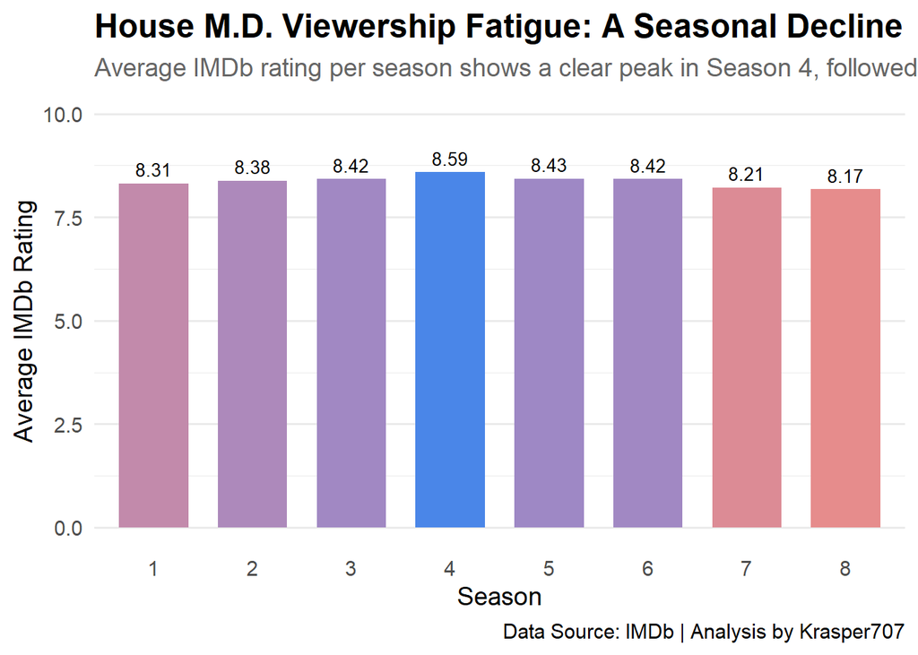

**Finding:** The show’s ratings peaked in Season 4, which is often cited by fans as one of its strongest. After this peak, there is a consistent, gradual decline in average ratings through the final season, suggesting a drop in audience satisfaction or general series fatigue.

# Analysis 2: The Best and Worst Episodes

While seasonal averages tell a broad story, individual episodes can be outliers. Identifying the highest and lowest-rated episodes highlights moments that resonated most (or least) with the audience.

[figure not shown]

**Finding:** The highest-rated episodes are dominated by season finales and pivotal character moments, such as “House’s Head” and “Wilson’s Heart.” Conversely, the lowest-rated episodes are primarily from the later seasons, which aligns with the overall downward trend in seasonal ratings.

# Analysis 3: Episode Ratings Over the Entire Series

To see the show’s pulse more granularly, we can plot the rating of every single episode in chronological order. This helps visualize volatility and the overall trend from the pilot to the finale.

[figure not shown]

# Analysis 4: Who Were the Key Players?

Finally, we can use our cast data to see which actors appeared in the most episodes, giving us a quantitative look at who the core cast members were over the show’s entire run.

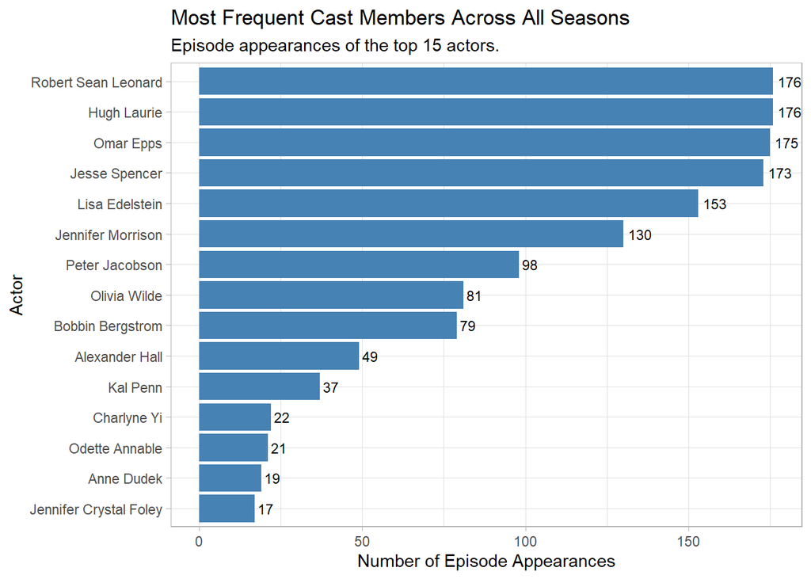

*This concludes the analysis. The data was scraped, cleaned, and visualized using R and the Tidyverse.*